# White Wine Analysis

Ishana Narayanan

June 5, 2020

```r
white <- read.csv("winequality-white.csv")
```

```r
library(leaps)
library(ggplot2)
library(reshape2)
library(MASS)
library(car)
```

# Part 1: Data Basics

- fixed acidity = numeric, continuous
- volatile acidity = numeric, continuous
- citric acid = numeric, continuous
- residual sugar = numeric, continuous
- chlorides = numeric, continuous
- free sulfur dioxide = numeric, continuous
- total sulfur dioxide = numeric, continuous
- density = numeric, continuous
- pH = numeric, continuous
- sulphates = numeric, continuous
- alcohol = numeric, continuous
- quality = categorical, ordinal

# Part 2: Visualizing Data

```r
mod.full = lm(white$alcohol ~ white$fixed.acidity + white$volatile.acidity + white$citric.acid + white$residual.sugar + white$chlorides + white$free.sulfur.dioxide + white$total.sulfur.dioxide + white$density + white$pH + white$sulphates + white$quality)
```

1. Scatterplot Matrix

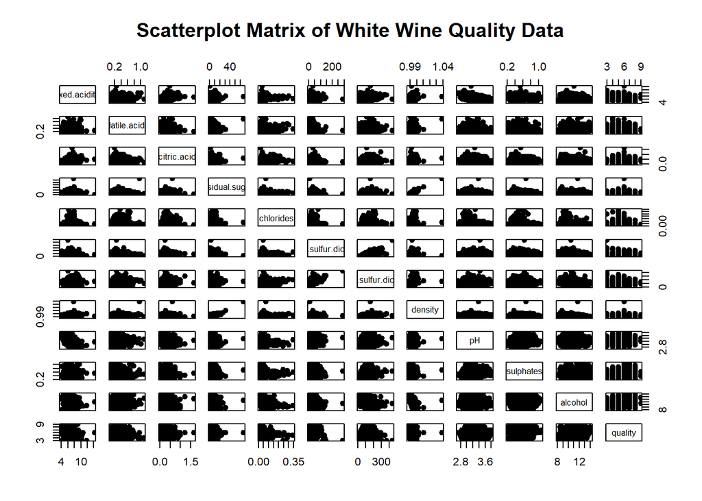

```r
pairs(white, main="Scatterplot Matrix of White Wine Quality Data", pch=19)
```

2. Correlation Matrix

```r
cor(white)
```

```
##                      fixed.acidity volatile.acidity  citric.acid
## fixed.acidity           1.00000000      -0.02269729  0.289180698
## volatile.acidity       -0.02269729       1.00000000 -0.149471811
## citric.acid             0.28918070      -0.14947181  1.000000000
## residual.sugar          0.08902070       0.06428606  0.094211624
## chlorides               0.02308564       0.07051157  0.114364448
## free.sulfur.dioxide    -0.04939586      -0.09701194  0.094077221
## total.sulfur.dioxide    0.09106976       0.08926050  0.121130798
## density                 0.26533101       0.02711385  0.149502571
## pH                     -0.42585829      -0.03191537 -0.163748211
## sulphates              -0.01714299      -0.03572815  0.062330940
## alcohol                -0.12088112       0.06771794 -0.075728730
## quality                -0.11366283      -0.19472297 -0.009209091
##                      residual.sugar   chlorides free.sulfur.dioxide
## fixed.acidity            0.08902070  0.02308564       -0.0493958591
## volatile.acidity         0.06428606  0.07051157       -0.0970119393
## citric.acid              0.09421162  0.11436445        0.0940772210
## residual.sugar           1.00000000  0.08868454        0.2990983537
## chlorides                0.08868454  1.00000000        0.1013923521
## free.sulfur.dioxide      0.29909835  0.10139235        1.0000000000
## total.sulfur.dioxide     0.40143931  0.19891030        0.6155009650
## density                  0.83896645  0.25721132        0.2942104109
## pH                      -0.19413345 -0.09043946       -0.0006177961
## sulphates               -0.02666437  0.01676288        0.0592172458
## alcohol                 -0.45063122 -0.36018871       -0.2501039415
## quality                 -0.09757683 -0.20993441        0.0081580671
##                      total.sulfur.dioxide     density            pH
## fixed.acidity                 0.091069756  0.26533101 -0.4258582910
## volatile.acidity              0.089260504  0.02711385 -0.0319153683
## citric.acid                   0.121130798  0.14950257 -0.1637482114
## residual.sugar                0.401439311  0.83896645 -0.1941334540
## chlorides                     0.198910300  0.25721132 -0.0904394560
## free.sulfur.dioxide           0.615500965  0.29421041 -0.0006177961
## total.sulfur.dioxide          1.000000000  0.52988132  0.0023209718
## density                       0.529881324  1.00000000 -0.0935914935
## pH                            0.002320972 -0.09359149  1.0000000000
## sulphates                     0.134562367  0.07449315  0.1559514973
## alcohol                      -0.448892102 -0.78013762  0.1214320987
## quality                      -0.174737218 -0.30712331  0.0994272457
##                        sulphates     alcohol      quality
## fixed.acidity        -0.01714299 -0.12088112 -0.113662831
## volatile.acidity     -0.03572815  0.06771794 -0.194722969
## citric.acid           0.06233094 -0.07572873 -0.009209091
## residual.sugar       -0.02666437 -0.45063122 -0.097576829
## chlorides             0.01676288 -0.36018871 -0.209934411
## free.sulfur.dioxide   0.05921725 -0.25010394  0.008158067
## total.sulfur.dioxide  0.13456237 -0.44889210 -0.174737218
## density               0.07449315 -0.78013762 -0.307123313
## pH                    0.15595150  0.12143210  0.099427246
## sulphates             1.00000000 -0.01743277  0.053677877
## alcohol              -0.01743277  1.00000000  0.435574715
## quality               0.05367788  0.43557472  1.000000000
```

From the correlation matrix above, we see that there is a moderately positive linear relationship between alcohol and quality with a correlation value of 0.43557.

Significant negative linear relationships:

- alcohol and residual sugar (-0.45)
- alcohol and total sulfur dioxide (-0.448)
- alcohol and density (-0.78)
- pH and fixed acidity (-0.4258)

Significant positive linear relationships:

- residual sugar and density (0.83)
- density and total sulfur dioxide (0.529)
- residual sugar and total sulfur dioxide (0.401)
- total sulfur dioxide and free sulfur dioxide (0.6155)
3. Correlation Heatmap

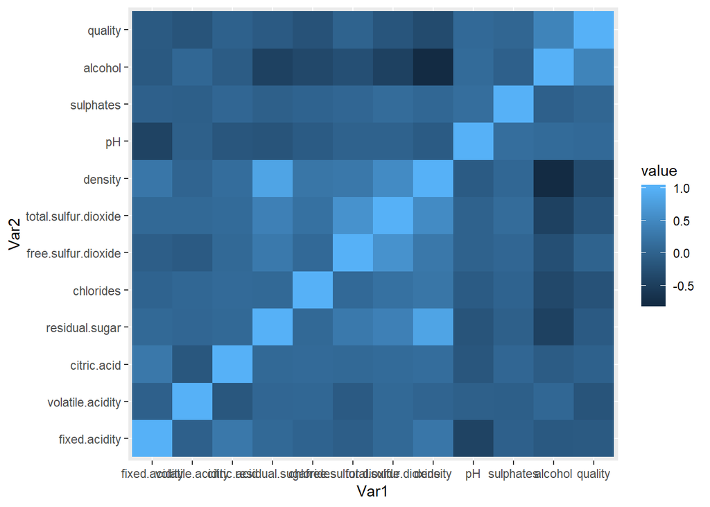

```r
corr_white <- round(cor(white),2)
melted_white <- melt(round(cor(white),2))
ggplot(melted_white, aes(x=Var1, y=Var2, fill=value)) + geom_tile()
```

```r
 get_lower_tri <- function(corr_white){
    corr_white[lower.tri(corr_white)]<- NA
    return(corr_white)
  }
```

```r
melted_white_lower <- melt(get_lower_tri(corr_white))
```

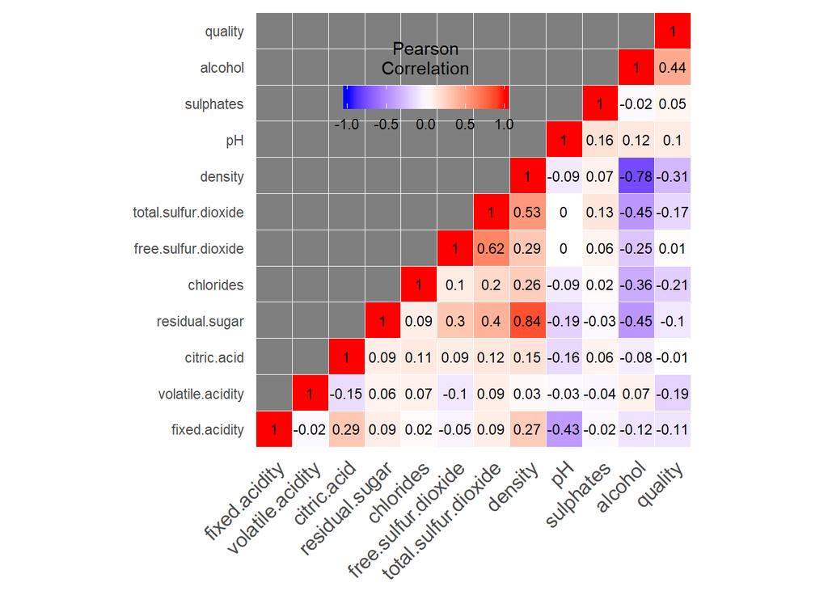

```r
ggheatmap <- ggplot(melted_white_lower, aes(Var2, Var1, fill = value))+
 geom_tile(color = "white")+
 scale_fill_gradient2(low = "blue", high = "red", mid = "white",
   midpoint = 0, limit = c(-1,1), space = "Lab",
    name="Pearson\nCorrelation") +
  theme_minimal()+ # minimal theme
 theme(axis.text.x = element_text(angle = 45, vjust = 1,
    size = 12, hjust = 1))+
 coord_fixed()

ggheatmap +
geom_text(aes(Var2, Var1, label = value), color = "black", size = 3) +
theme(
  axis.title.x = element_blank(),
  axis.title.y = element_blank(),
  panel.grid.major = element_blank(),
  panel.border = element_blank(),
  panel.background = element_blank(),
  axis.ticks = element_blank(),
  legend.justification = c(1, 0),
  legend.position = c(0.6, 0.7),
  legend.direction = "horizontal")+
  guides(fill = guide_colorbar(barwidth = 7, barheight = 1,
                title.position = "top", title.hjust = 0.5))
```

# Part 3: Regression Analysis

## Best Subsets Regression

### Fitting Model

```r
mod = regsubsets(cbind(white$fixed.acidity, white$volatile.acidity, white$citric.acid, white$residual.sugar, white$chlorides, white$free.sulfur.dioxide, white$total.sulfur.dioxide, white$density, white$pH, white$sulphates, white$quality), white$alcohol)
summary.mod = summary(mod)
summary.mod$which
```

```
##   (Intercept)     a     b     c     d     e     f     g    h     i     j
## 1        TRUE FALSE FALSE FALSE FALSE FALSE FALSE FALSE TRUE FALSE FALSE
## 2        TRUE FALSE FALSE FALSE  TRUE FALSE FALSE FALSE TRUE FALSE FALSE
## 3        TRUE  TRUE FALSE FALSE  TRUE FALSE FALSE FALSE TRUE FALSE FALSE
## 4        TRUE  TRUE FALSE FALSE  TRUE FALSE FALSE FALSE TRUE  TRUE FALSE
## 5        TRUE  TRUE FALSE FALSE  TRUE FALSE FALSE FALSE TRUE  TRUE  TRUE
## 6        TRUE  TRUE  TRUE FALSE  TRUE FALSE FALSE FALSE TRUE  TRUE  TRUE
## 7        TRUE  TRUE  TRUE FALSE  TRUE FALSE FALSE FALSE TRUE  TRUE  TRUE
## 8        TRUE  TRUE  TRUE FALSE  TRUE FALSE  TRUE FALSE TRUE  TRUE  TRUE
##       k
## 1 FALSE
## 2 FALSE
## 3 FALSE
## 4 FALSE
## 5 FALSE
## 6 FALSE
## 7  TRUE
## 8  TRUE
```

1. $R^2$

```r
summary.mod$rsq
```

```
## [1] 0.6086147 0.7489771 0.7854561 0.8541622 0.8627879 0.8678310 0.8693754
## [8] 0.8705191
```

2. Adjusted $R^2$

```r
summary.mod$adjr2
```

```
## [1] 0.6085348 0.7488746 0.7853246 0.8540430 0.8626477 0.8676689 0.8691884
## [8] 0.8703072
```

3. Mallow’s Cp Statistic

```r
summary.mod$cp
```

```
## [1] 10036.53994  4684.00336  3294.40613   675.40884   348.35625   157.97337
## [7]   101.05863    59.43043
```

According to the adjusted $R^2$ and Mallow’s Cp statistic, the best model is one with 8 predictors. Those predictors are fixed acidity, volatile acidity, residual sugar, free sulfur dioxide, density, pH, sulphates, and quality.

### Residual Analysis

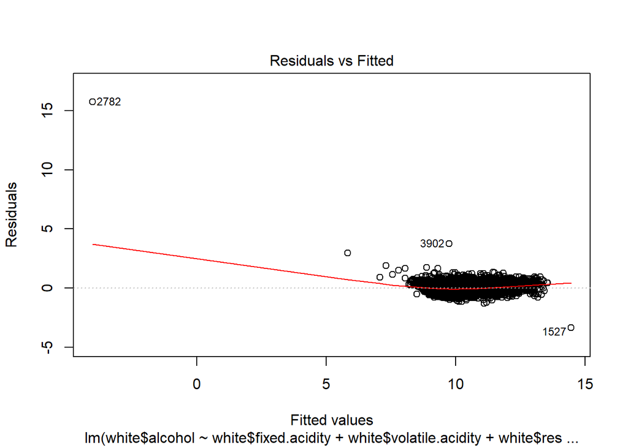

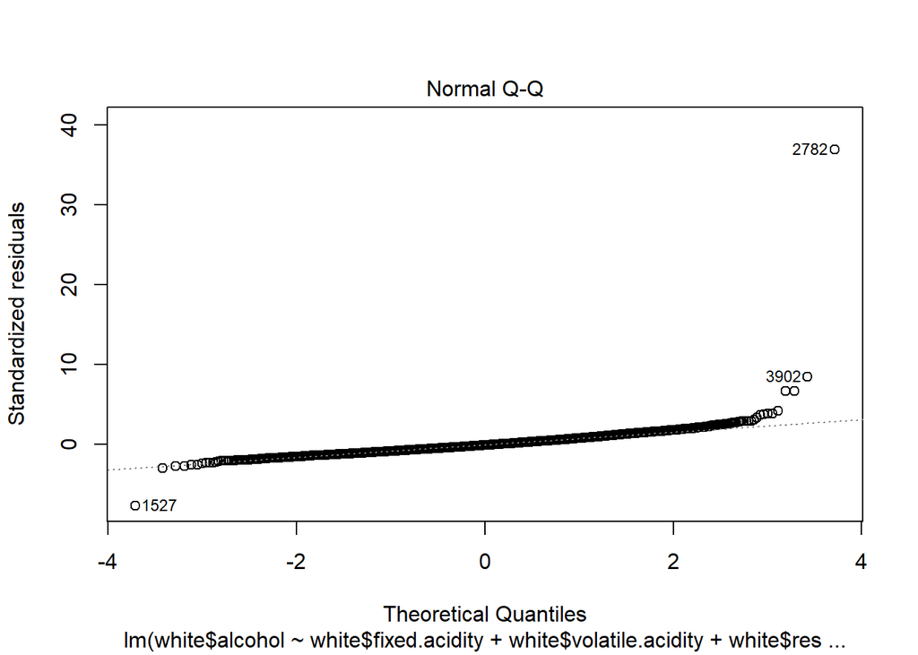

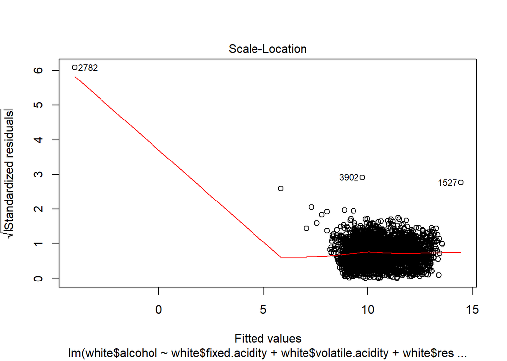

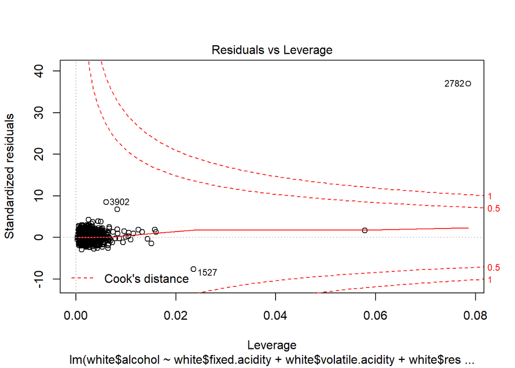

```r
fit_subset = lm(white$alcohol ~ white$fixed.acidity + white$volatile.acidity + white$residual.sugar + white$free.sulfur.dioxide + white$density + white$pH + white$sulphates + white$quality)

plot(fit_subset)
```

According to the Residuals vs. Fit plot, we see that there are extreme outliers impacting these plots. We should remove the outliers so that we have a better understanding of what these plots are depicting.

### Removing Outliers

1. Outliers

```r
out = rstudent(fit_subset)
which(abs(out) > 3)
```

```
## 1321 1418 1527 1654 1664 2731 2732 2782 3140 3620 3624 3902
## 1321 1418 1527 1654 1664 2731 2732 2782 3140 3620 3624 3902
```

2. Influential Points

```r
hv <- hatvalues(fit_subset)
threshold <- 3*sum(hatvalues(fit_subset))/nrow(white)
which(abs(hv) > threshold)
```

```
##   18   21  252  254  295  326  373  446  660  775  874  949 1035 1041 1246
##   18   21  252  254  295  326  373  446  660  775  874  949 1035 1041 1246
## 1477 1527 1654 1664 1689 1857 1932 1933 1952 2051 2093 2155 2322 2335 2337
## 1477 1527 1654 1664 1689 1857 1932 1933 1952 2051 2093 2155 2322 2335 2337
## 2404 2418 2442 2595 2626 2630 2669 2749 2751 2782 2873 2875 2931 3051 3098
## 2404 2418 2442 2595 2626 2630 2669 2749 2751 2782 2873 2875 2931 3051 3098
## 3266 3308 3462 3471 3529 3621 3711 3737 3774 3902 4040 4260 4402 4481 4697
## 3266 3308 3462 3471 3529 3621 3711 3737 3774 3902 4040 4260 4402 4481 4697
## 4746 4793 4816 4887
## 4746 4793 4816 4887
```

3. Cook’s Distance

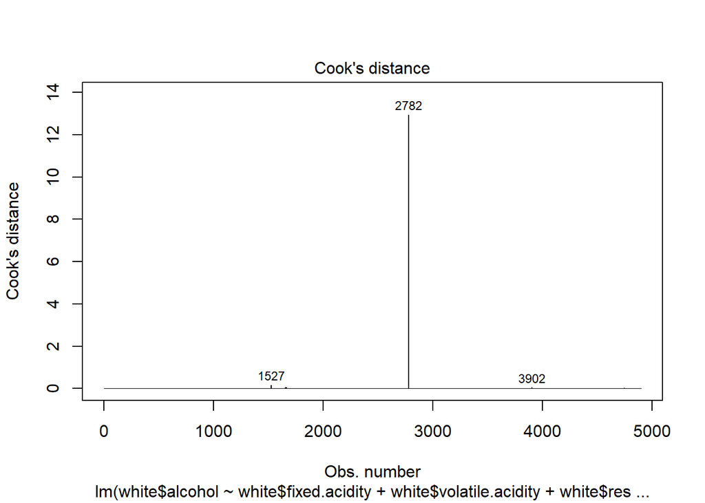

```r
cook <- cooks.distance(fit_subset)
plot(fit_subset, which=4)
```

```r
new_white <- white[-c(1527, 1654, 1664, 2782, 3902),]
```

### Returning to Residual Analysis

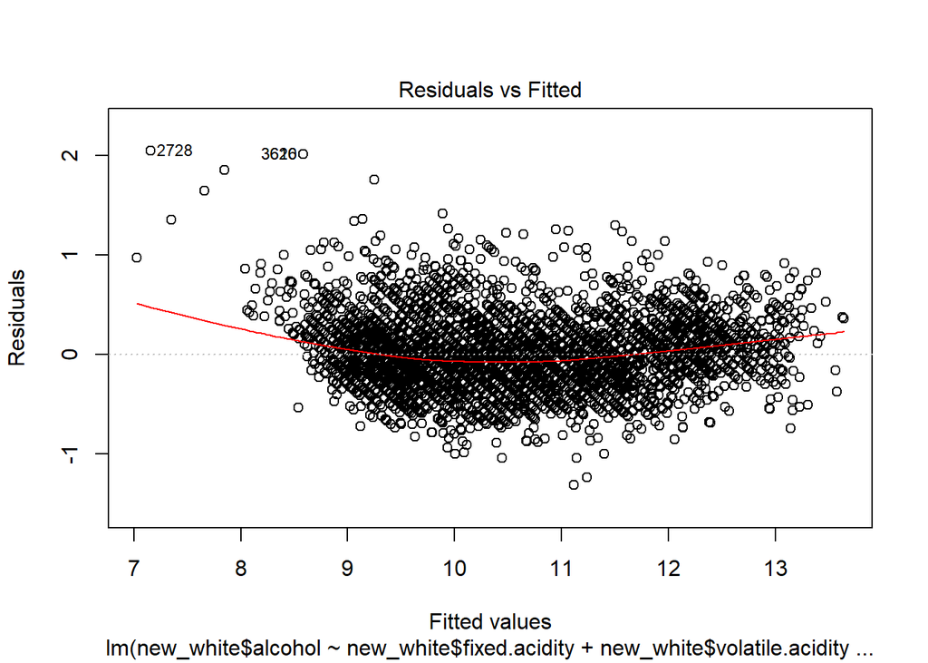

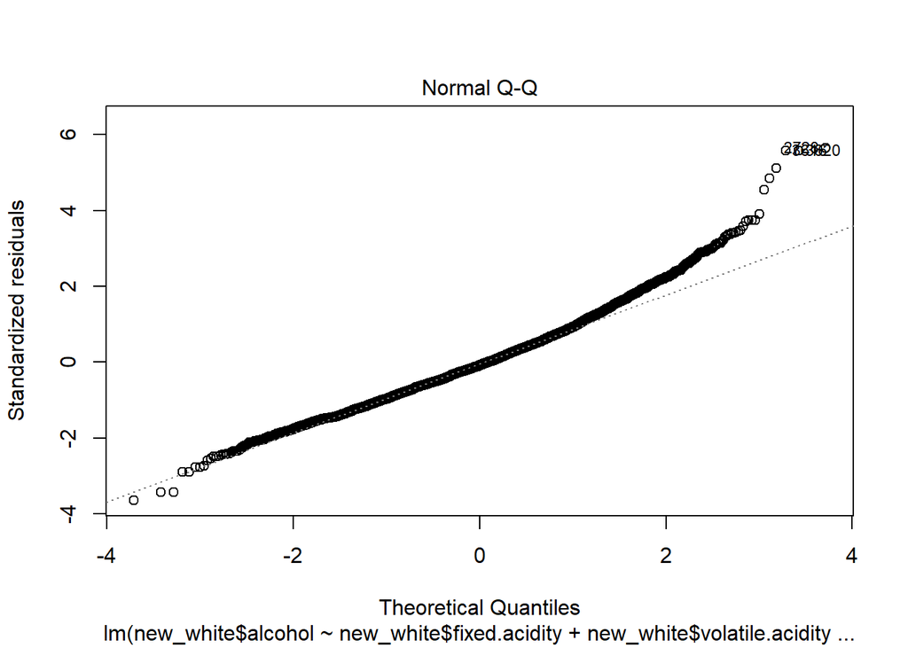

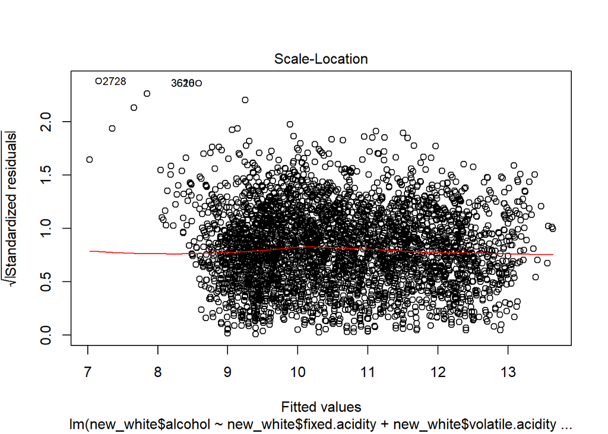

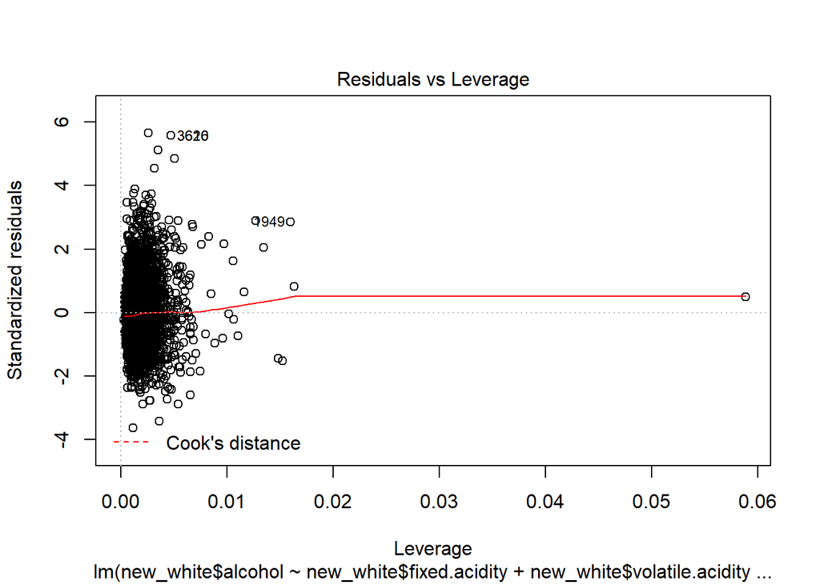

```r
fit_sub_no_outliers = lm(new_white$alcohol ~ new_white$fixed.acidity + new_white$volatile.acidity + new_white$residual.sugar + new_white$free.sulfur.dioxide + new_white$density + new_white$pH + new_white$sulphates + new_white$quality)
plot(fit_sub_no_outliers)
```

- In the Residuals vs. Fit plot, since the residuals are evenly spread about $x=0$ without any fanning, we can conclude that the error variances are equal. Moreover, this even spread of residuals, indicating that a linear model is a good fit.
- In the Normal Q-Q plot, the residuals are relatively following the curve. It is possible that this model is violating the non-normality LINE condition, so a transformation is needed to further investigate.
- There are still a few outliers, but not nearly as many in the previous Residuals vs. Fit plot.
- Thus, we can assume that from the above information that our model relatively meets the LINE conditions.

```r
summary(fit_sub_no_outliers)
```

```
##
## Call:
## lm(formula = new_white$alcohol ~ new_white$fixed.acidity + new_white$volatile.acidity +
##     new_white$residual.sugar + new_white$free.sulfur.dioxide +
##     new_white$density + new_white$pH + new_white$sulphates +
##     new_white$quality)
##
## Residuals:
##      Min       1Q   Median       3Q      Max
## -1.31797 -0.23667 -0.02988  0.20688  2.04486
##
## Coefficients:
##                                 Estimate Std. Error  t value Pr(>|t|)
## (Intercept)                    7.094e+02  4.157e+00  170.639  < 2e-16 ***
## new_white$fixed.acidity        5.622e-01  7.846e-03   71.664  < 2e-16 ***
## new_white$volatile.acidity     6.362e-01  5.365e-02   11.859  < 2e-16 ***
## new_white$residual.sugar       2.427e-01  2.298e-03  105.651  < 2e-16 ***
## new_white$free.sulfur.dioxide -9.034e-04  3.274e-04   -2.759 0.005820 **
## new_white$density             -7.171e+02  4.249e+00 -168.778  < 2e-16 ***
## new_white$pH                   2.421e+00  4.181e-02   57.901  < 2e-16 ***
## new_white$sulphates            1.057e+00  4.697e-02   22.510  < 2e-16 ***
## new_white$quality              2.514e-02  6.909e-03    3.638 0.000277 ***
## ---
## Signif. codes:  0 '***' 0.001 '**' 0.01 '*' 0.05 '.' 0.1 ' ' 1
##
## Residual standard error: 0.3622 on 4884 degrees of freedom
## Multiple R-squared:  0.9134, Adjusted R-squared:  0.9133
## F-statistic:  6441 on 8 and 4884 DF,  p-value: < 2.2e-16
```

## Stepwise Regression

### Build Regression Model

```r
mod0 = lm(white$alcohol ~ 1)
mod.full = lm(white$alcohol ~ white$fixed.acidity + white$volatile.acidity + white$citric.acid + white$residual.sugar + white$chlorides + white$free.sulfur.dioxide + white$total.sulfur.dioxide + white$density + white$pH + white$sulphates + white$quality)
step(mod0, scope=list(lower=mod0, upper=mod.full))
```

```
## Start:  AIC=2033.85
## white$alcohol ~ 1
##
##                              Df Sum of Sq    RSS      AIC
## + white$density               1    4513.6 2902.6 -2558.78
## + white$residual.sugar        1    1506.0 5910.2   924.07
## + white$total.sulfur.dioxide  1    1494.4 5921.8   933.68
## + white$quality               1    1407.0 6009.1  1005.40
## + white$chlorides             1     962.1 6454.0  1355.23
## + white$free.sulfur.dioxide   1     463.9 6952.3  1719.47
## + white$pH                    1     109.4 7306.8  1963.09
## + white$fixed.acidity         1     108.4 7307.8  1963.75
## + white$citric.acid           1      42.5 7373.6  2007.68
## + white$volatile.acidity      1      34.0 7382.1  2013.34
## <none>                                    7416.1  2033.85
## + white$sulphates             1       2.3 7413.9  2034.36
##
## Step:  AIC=-2558.78
## white$alcohol ~ white$density
##
##                              Df Sum of Sq    RSS     AIC
## + white$residual.sugar        1    1040.9 1861.6 -4732.2
## + white$quality               1     314.5 2588.1 -3118.5
## + white$chlorides             1     202.1 2700.5 -2910.3
## + white$fixed.acidity         1      59.2 2843.4 -2657.6
## + white$volatile.acidity      1      58.6 2844.0 -2656.7
## + white$pH                    1      17.5 2885.0 -2586.5
## + white$total.sulfur.dioxide  1      13.0 2889.6 -2578.8
## + white$citric.acid           1      12.7 2889.9 -2578.2
## + white$sulphates             1      12.3 2890.2 -2577.7
## + white$free.sulfur.dioxide   1       3.4 2899.1 -2562.6
## <none>                                    2902.6 -2558.8
## - white$density               1    4513.6 7416.1  2033.9
##
## Step:  AIC=-4732.22
## white$alcohol ~ white$density + white$residual.sugar
##
##                              Df Sum of Sq    RSS     AIC
## + white$fixed.acidity         1     270.5 1591.1 -5499.4
## + white$pH                    1     128.5 1733.2 -5080.4
```

[output cut: 141 more lines]

```
##     white$free.sulfur.dioxide + white$citric.acid + white$total.sulfur.dioxide
##
##                              Df Sum of Sq    RSS     AIC
## <none>                                     949.9 -8011.7
## + white$chlorides             1      0.06  949.9 -8010.0
## - white$total.sulfur.dioxide  1      1.71  951.6 -8004.9
## - white$citric.acid           1      8.25  958.2 -7971.3
## - white$free.sulfur.dioxide   1     10.78  960.7 -7958.4
## - white$quality               1     12.42  962.3 -7950.1
## - white$volatile.acidity      1     40.05  990.0 -7811.4
## - white$sulphates             1     55.19 1005.1 -7737.1
## - white$pH                    1    429.08 1379.0 -6188.0
## - white$fixed.acidity         1    549.16 1499.1 -5779.1
## - white$residual.sugar        1   1344.73 2294.7 -3693.9
## - white$density               1   3122.99 4072.9  -883.5
```

```
##
## Call:
## lm(formula = white$alcohol ~ white$density + white$residual.sugar +
##     white$fixed.acidity + white$pH + white$sulphates + white$volatile.acidity +
##     white$quality + white$free.sulfur.dioxide + white$citric.acid +
##     white$total.sulfur.dioxide)
##
## Coefficients:
##                (Intercept)               white$density
##                  6.730e+02                  -6.804e+02
##       white$residual.sugar         white$fixed.acidity
##                  2.347e-01                   5.112e-01
##                   white$pH             white$sulphates
##                  2.389e+00                   9.682e-01
##     white$volatile.acidity               white$quality
##                  9.599e-01                   6.666e-02
##  white$free.sulfur.dioxide           white$citric.acid
##                 -3.673e-03                   3.624e-01
## white$total.sulfur.dioxide
##                  6.567e-04
```

Model: alcohol ~ density + residual sugar + fixed acidity + pH + sulphates + volatile acidity + quality + free sulfur dioxide + citric acid + total sulfur dioxide

### Residual Analysis

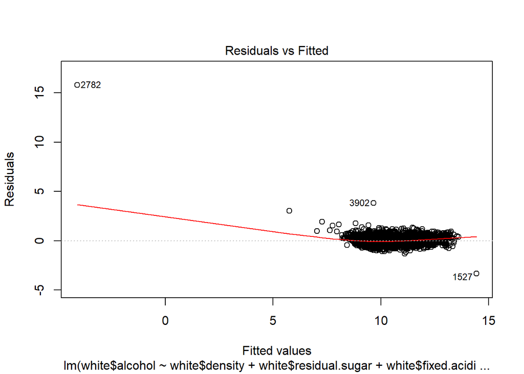

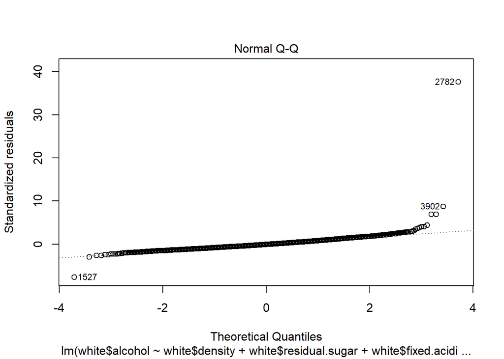

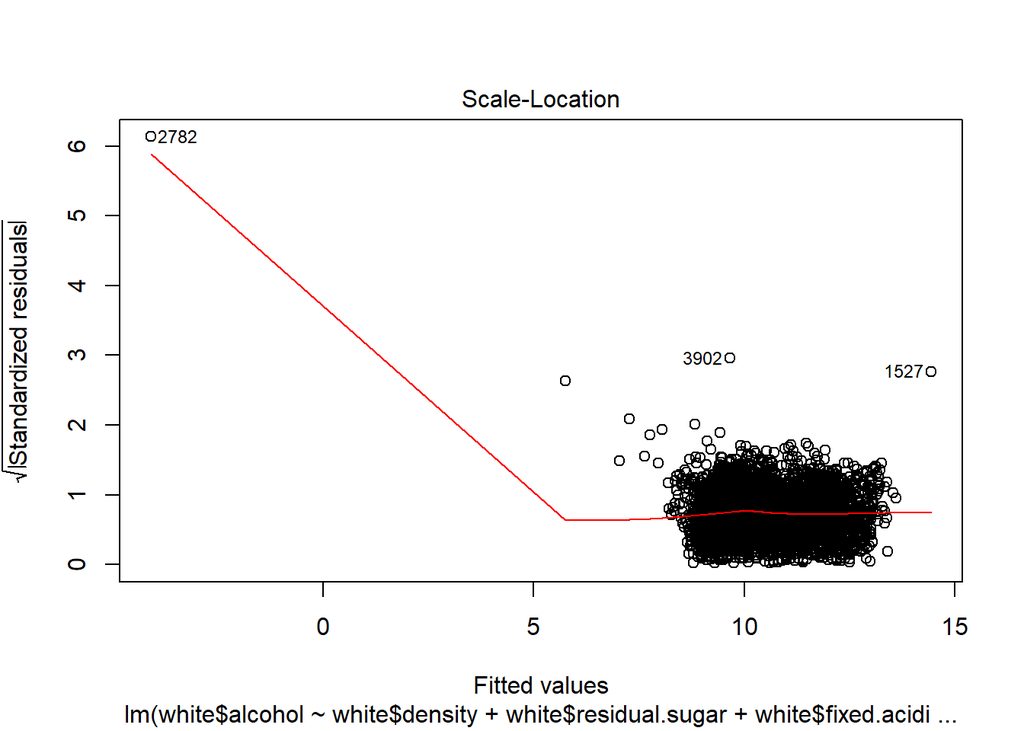

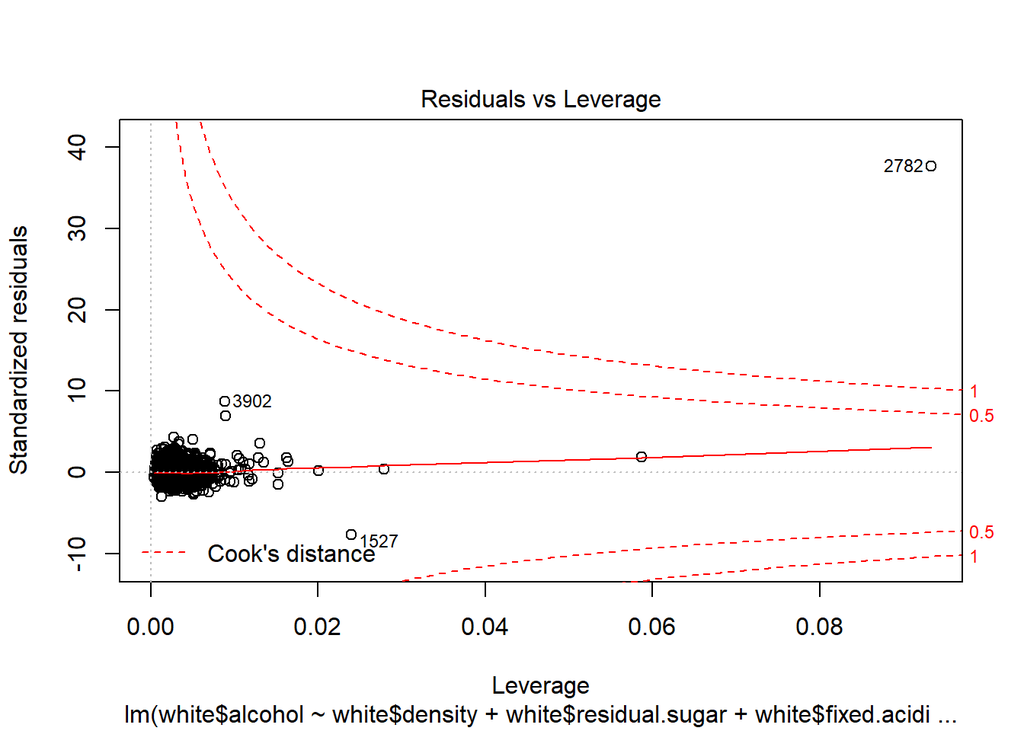

```r
fit_step = lm(white$alcohol ~ white$density + white$residual.sugar + white$fixed.acidity + white$pH + white$sulphates + white$volatile.acidity + white$quality + white$free.sulfur.dioxide + white$citric.acid + white$total.sulfur.dioxide)
plot(fit_step)
```

According to the Residuals vs. Fit plot, we see that there are extreme outliers impacting these plots. We should remove the outliers so that we have a better understanding of what these plots are depicting.

### Removing Outliers

1. Outliers

```r
out = rstudent(fit_step)
which(abs(out) > 3)
```

```
## 1321 1418 1527 1654 1664 2731 2732 2782 3140 3620 3624 3902 4534
## 1321 1418 1527 1654 1664 2731 2732 2782 3140 3620 3624 3902 4534
```

2. Influential Points

```r
hv <- hatvalues(fit_step)
threshold <- 3*sum(hatvalues(fit_step))/nrow(white)
which(abs(hv) > threshold)
```

```
##   18   21  208  246  254  326  373  660  746  874  947  949 1035 1246 1305
##   18   21  208  246  254  326  373  660  746  874  947  949 1035 1246 1305
## 1418 1477 1527 1552 1654 1664 1689 1723 1776 1857 1932 1933 1952 2051 2093
## 1418 1477 1527 1552 1654 1664 1689 1723 1776 1857 1932 1933 1952 2051 2093
## 2128 2155 2187 2335 2418 2442 2669 2749 2751 2782 2873 2875 2931 3044 3051
## 2128 2155 2187 2335 2418 2442 2669 2749 2751 2782 2873 2875 2931 3044 3051
## 3098 3153 3266 3308 3498 3529 3572 3621 3711 3737 3774 3880 3902 3912 4040
## 3098 3153 3266 3308 3498 3529 3572 3621 3711 3737 3774 3880 3902 3912 4040
## 4260 4481 4592 4627 4633 4746 4793 4816 4887
## 4260 4481 4592 4627 4633 4746 4793 4816 4887
```

3. Cook’s Distance

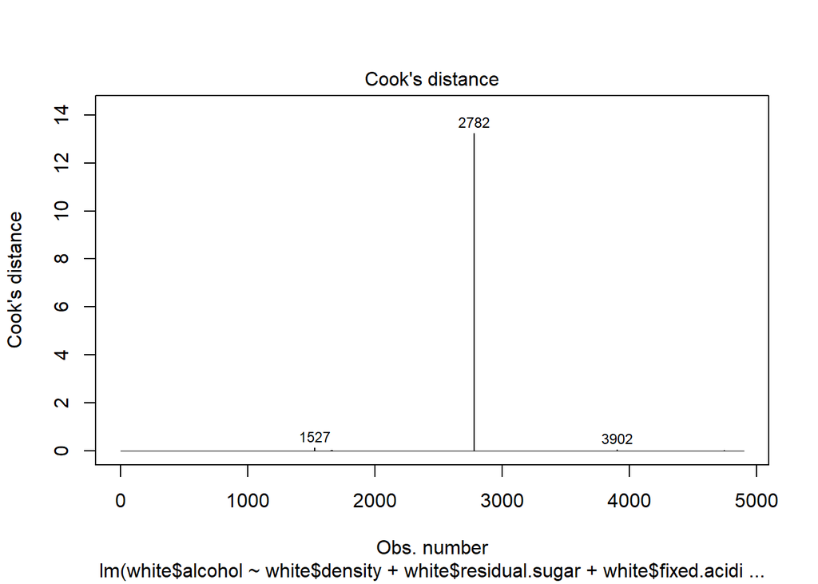

```r
cook <- cooks.distance(fit_step)
plot(fit_step, which=4)
```

```r
new_white <- white[-c(1527, 1654, 1664, 2782, 3902),]
```

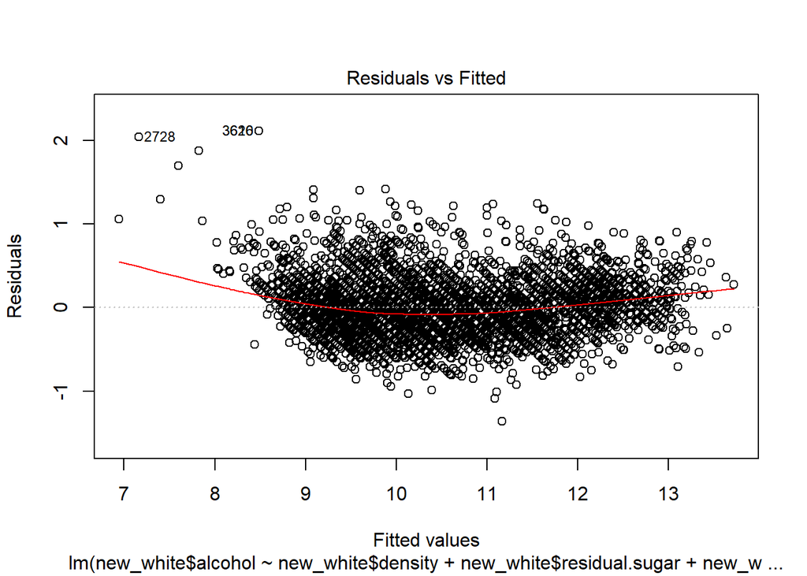

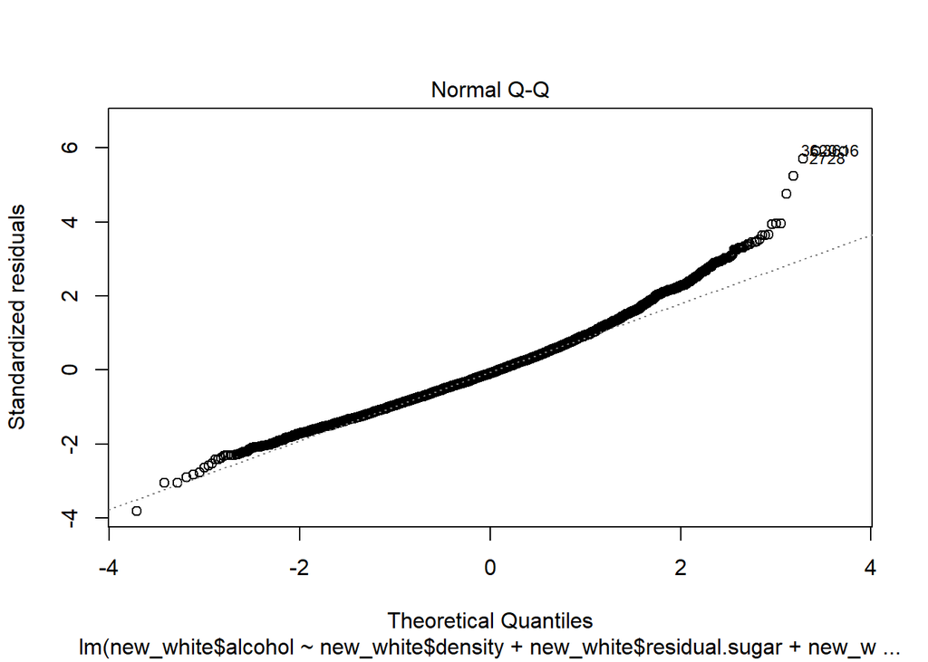

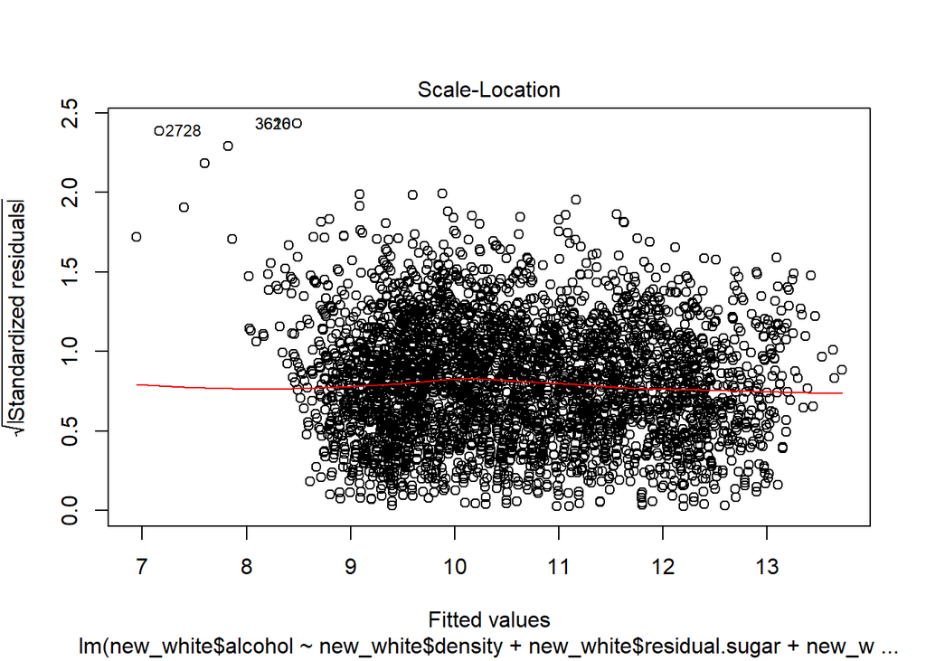

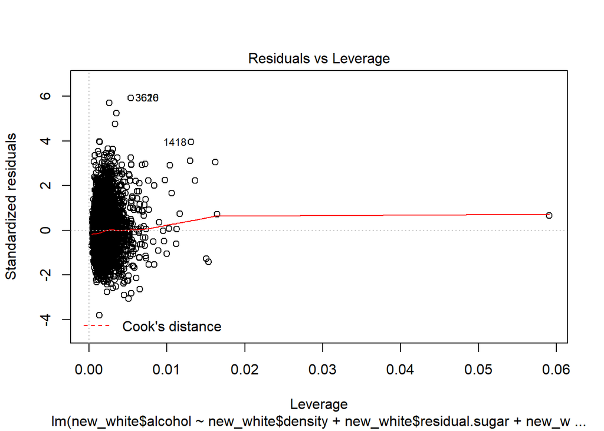

```r
fit_step_no_outliers = lm(new_white$alcohol ~ new_white$density + new_white$residual.sugar + new_white$fixed.acidity + new_white$pH + new_white$sulphates + new_white$volatile.acidity + new_white$quality + new_white$free.sulfur.dioxide + new_white$total.sulfur.dioxide)
plot(fit_step_no_outliers)
```

The residuals for the best subsets and stepwise regression models look relatively the same. Therefore, we should go with the model which has greater simplicity. Thus, the model we are going to further examine is the best subsets regression model.

Model: fit_subset = alcohol ~ fixed.acidity + volatile.acidity + residual.sugar + free.sulfur.dioxide + density + pH + sulphates + quality)

```r
summary(fit_step_no_outliers)
```

```
##
## Call:
## lm(formula = new_white$alcohol ~ new_white$density + new_white$residual.sugar +
##     new_white$fixed.acidity + new_white$pH + new_white$sulphates +
##     new_white$volatile.acidity + new_white$quality + new_white$free.sulfur.dioxide +
##     new_white$total.sulfur.dioxide)
##
## Residuals:
##      Min       1Q   Median       3Q      Max
## -1.36486 -0.24295 -0.03235  0.20446  2.11256
##
## Coefficients:
##                                  Estimate Std. Error  t value Pr(>|t|)
## (Intercept)                     7.264e+02  4.394e+00  165.308  < 2e-16 ***
## new_white$density              -7.343e+02  4.487e+00 -163.650  < 2e-16 ***
## new_white$residual.sugar        2.470e-01  2.304e-03  107.197  < 2e-16 ***
## new_white$fixed.acidity         5.641e-01  7.755e-03   72.741  < 2e-16 ***
## new_white$pH                    2.421e+00  4.131e-02   58.604  < 2e-16 ***
## new_white$sulphates             1.015e+00  4.658e-02   21.801  < 2e-16 ***
## new_white$volatile.acidity      5.087e-01  5.430e-02    9.368  < 2e-16 ***
## new_white$quality               2.437e-02  6.828e-03    3.569 0.000362 ***
## new_white$free.sulfur.dioxide  -3.466e-03  4.004e-04   -8.657  < 2e-16 ***
## new_white$total.sulfur.dioxide  1.972e-03  1.815e-04   10.870  < 2e-16 ***
## ---
## Signif. codes:  0 '***' 0.001 '**' 0.01 '*' 0.05 '.' 0.1 ' ' 1
##
## Residual standard error: 0.3579 on 4883 degrees of freedom
## Multiple R-squared:  0.9155, Adjusted R-squared:  0.9153
## F-statistic:  5876 on 9 and 4883 DF,  p-value: < 2.2e-16
```

## Part 4: Transformations, Residual Analysis, and LINE Conditions

Since non-normality may potentially be an issue, we should take a log transformation on Y.

## 1. Log Transformation on Y

```r
fit_y = lm(log(new_white$alcohol) ~ new_white$fixed.acidity + new_white$volatile.acidity + new_white$residual.sugar + new_white$free.sulfur.dioxide + new_white$density + new_white$pH + new_white$sulphates + new_white$quality)
```

## Residual Analysis

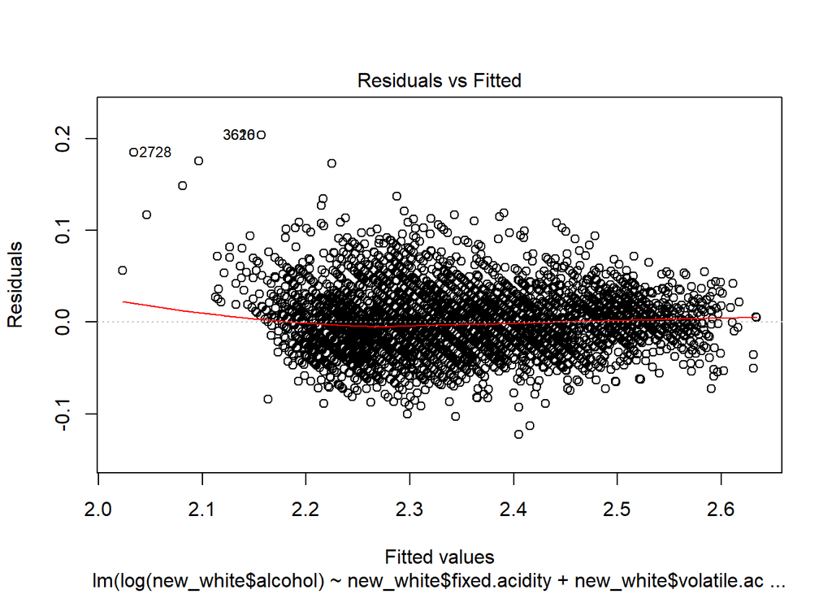

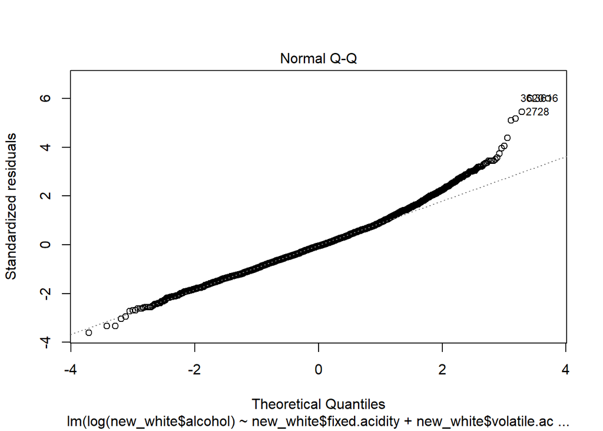

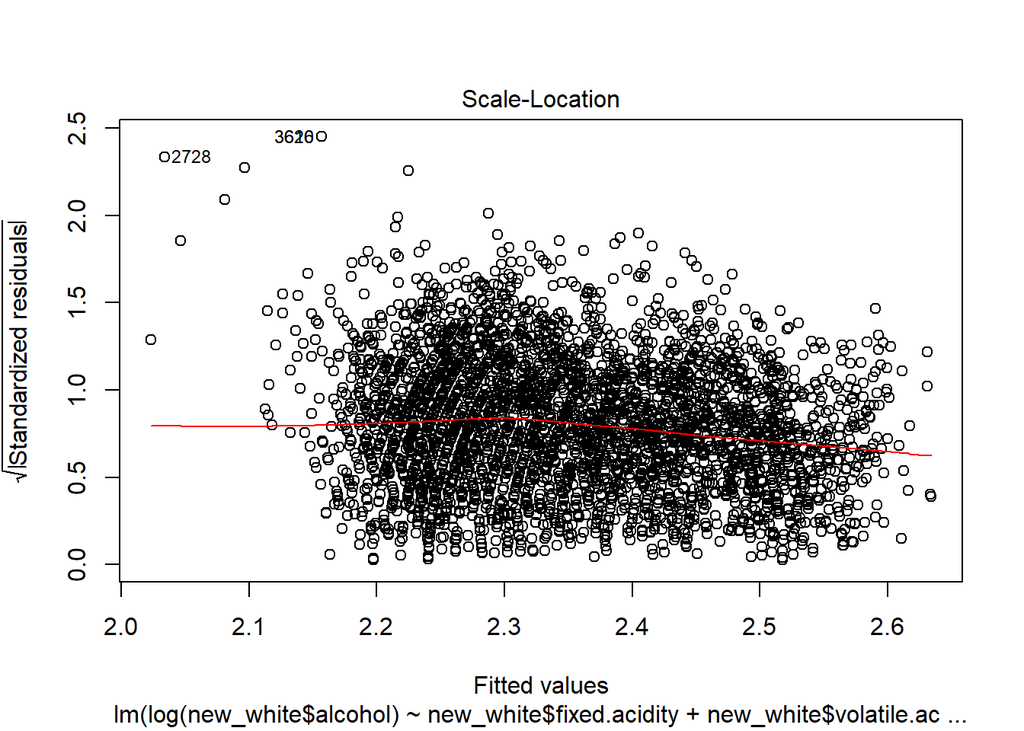

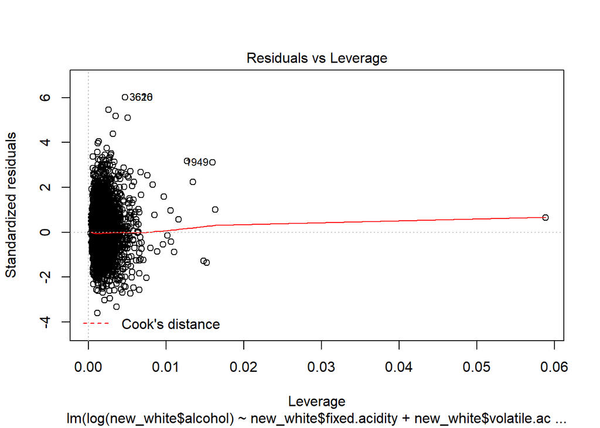

```r
plot(fit_y)
```

## 2. BoxCox Transformation

```r
trans=boxcox(fit_sub_no_outliers)
```

[figure not shown]

```r
# (1) find the appropriate lambda based on max likelihood

# lambda based on max likelihood
lambda = trans$x[trans$y==max(trans$y)]
print(lambda)
```

```
## [1] 0.06060606
```

```r
# (2) apply transformation
new_alcohol = (new_white$alcohol)^lambda
```

lambda = 0.060606

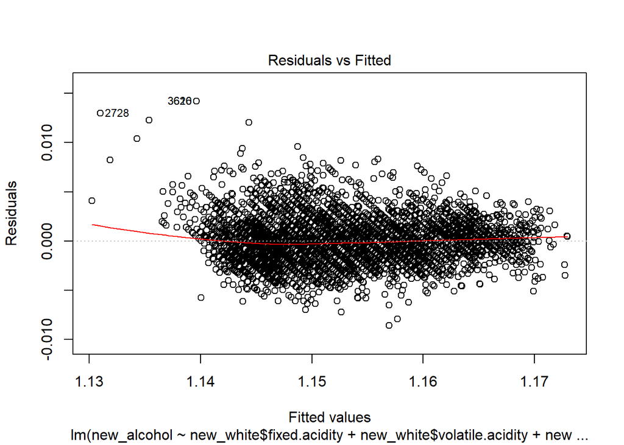

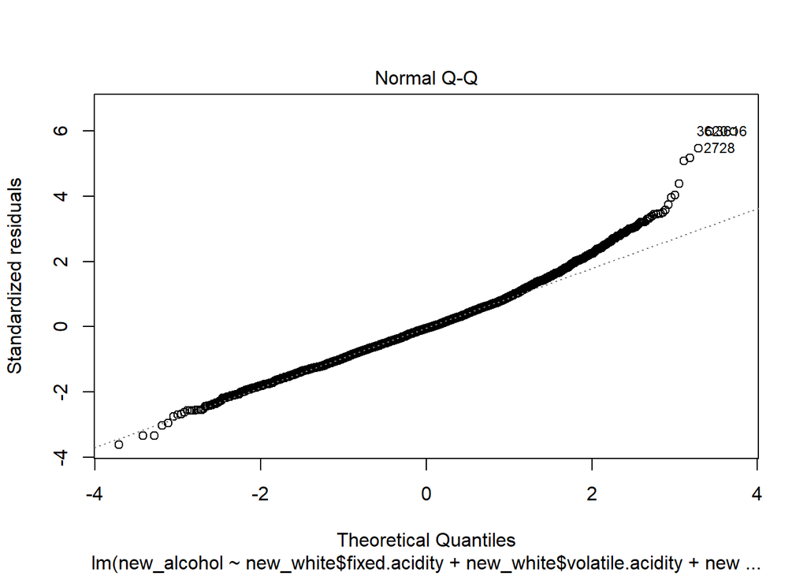

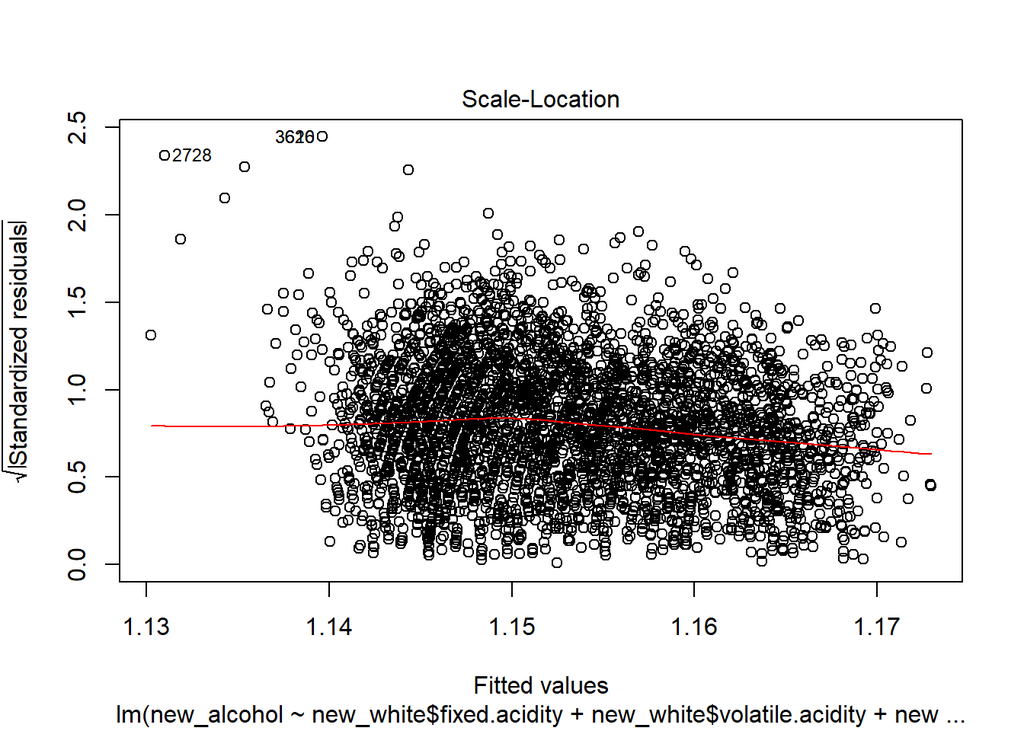

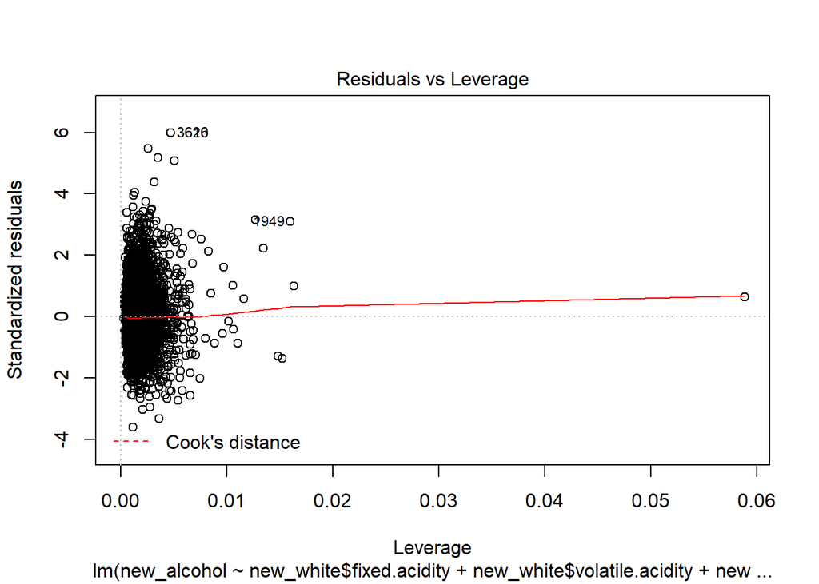

```r
fit_boxcox = lm(new_alcohol ~ new_white$fixed.acidity + new_white$volatile.acidity + new_white$residual.sugar + new_white$free.sulfur.dioxide + new_white$density + new_white$pH + new_white$sulphates + new_white$quality)
plot(fit_boxcox)
```

From the above transformations, we see that there are no significant changes with either a log transformation on Y or a BoxCox transformation.

# Answering Research Questions

## Which factors affect alcohol content the most for white wine?

$H_0:$ $\beta_1$ = $\beta_2$ = $\beta_3$ = $\beta_4$ = $\beta_5$ = $\beta_6$ = $\beta_7$= $\beta_8$ = 0

$H_a:$ at least one $\beta_k \neq 0$ for $k=1,2,3,4,5,6,7,8$

```r
mod.red = lm(new_white$alcohol ~ 1)
mod.full = fit_sub_no_outliers
anova(mod.red, mod.full)
```

```
## Analysis of Variance Table
##
## Model 1: new_white$alcohol ~ 1
## Model 2: new_white$alcohol ~ new_white$fixed.acidity + new_white$volatile.acidity +
##     new_white$residual.sugar + new_white$free.sulfur.dioxide +
##     new_white$density + new_white$pH + new_white$sulphates +
##     new_white$quality
##   Res.Df    RSS Df Sum of Sq      F    Pr(>F)
## 1   4892 7399.6
## 2   4884  640.6  8      6759 6441.5 < 2.2e-16 ***
## ---
## Signif. codes:  0 '***' 0.001 '**' 0.01 '*' 0.05 '.' 0.1 ' ' 1
```

Since the p-value of 2.2e-16 < $\alpha=0.05$, we must reject the null hypothesis. Therefore, not all $\beta_1 = \beta_2 = \beta_3 = \beta_4 = \beta_5 = \beta_6 = \beta_7= \beta_8 = 0$. There is sufficient evidence to conclude that some of the variation in alcohol content is explained by one or more of these predictors.

## Is the quality and density of wine significant in predicting the amount of alcohol in a particular wine?

$H_0:$ $\beta_5$ = $\beta_8$ = 0

$H_a:$ at least one $\beta_k \neq 0$ for $k=5,8$

```r
mod.red = lm(new_white$alcohol ~ new_white$fixed.acidity + new_white$volatile.acidity + new_white$residual.sugar + new_white$free.sulfur.dioxide + new_white$pH + new_white$sulphates)
mod.full = fit_sub_no_outliers
anova(mod.red,mod.full)
```

```
## Analysis of Variance Table
##
## Model 1: new_white$alcohol ~ new_white$fixed.acidity + new_white$volatile.acidity +
##     new_white$residual.sugar + new_white$free.sulfur.dioxide +
##     new_white$pH + new_white$sulphates
## Model 2: new_white$alcohol ~ new_white$fixed.acidity + new_white$volatile.acidity +
##     new_white$residual.sugar + new_white$free.sulfur.dioxide +
##     new_white$density + new_white$pH + new_white$sulphates +
##     new_white$quality
##   Res.Df    RSS Df Sum of Sq     F    Pr(>F)
## 1   4886 5643.0
## 2   4884  640.6  2    5002.4 19070 < 2.2e-16 ***
## ---
## Signif. codes:  0 '***' 0.001 '**' 0.01 '*' 0.05 '.' 0.1 ' ' 1
```

## What is the expected amount of alcohol in wine when all other factors are average?

```r
alcohol <- new_white$alcohol
fixed_acidity <- new_white$fixed.acidity
volatile_acidity <- new_white$volatile.acidity
residual_sugar <- new_white$residual.sugar
free_sulfur <- new_white$free.sulfur.dioxide
density <- new_white$density
pH <- new_white$pH
sulphates <- new_white$sulphates
quality <- new_white$quality
```

```r
fit = lm(alcohol ~ fixed_acidity + volatile_acidity + residual_sugar + free_sulfur + density + pH + sulphates + quality)

avg = data.frame(fixed_acidity = mean(fixed_acidity), volatile_acidity = mean(volatile_acidity), residual_sugar = mean(residual_sugar), free_sulfur = mean(free_sulfur), density = mean(density), pH = mean(pH), sulphates = mean(sulphates), quality = mean(quality))

predict(fit, avg, interval="confidence", level = .95)
```

```
##      fit      lwr      upr
## 1 10.514 10.50385 10.52415
```

We are 95% confident that the expected alcohol content is between 10.504 and 10.524 percent given that all other variables are averaged.